# Recommendation of Coupons In Vehicle

This notebook looks into using various Python-based machine learning and data science libraries in an attempt to build a machine learning model capable of predicting whether or not someone will accept a coupon by given his/her answers to some survey questions.

We're going to take the following approach:

1. Problem definition
2. Data
3. Evaluation
4. Features
5. Modelling
6. Experimentation

## 1. Problem Definition

In a statement,

> We are predicting , a user will accept a coupon by given his/her answers to some survey questions.

## 2. Data

There is also a version of it available on Kaggle. https://www.kaggle.com/datasets/mathurinache/invehicle-coupon-recommendation

## 3. Evaluation

> If we can reach 95% accuracy at predicting whether or not to coupon given.

## 4. Features

This is where you'll get different information about each of the features in your data. You can do this via doing your own research (such as looking at the links above) or by talking to a subject matter expert (someone who knows about the dataset).

**User attributes**

- gender: male, female
- age: 21, 46, 26, 31, 41, 50plus, 36, below21 (e.g. 21 means 21 to 26, 26 means 26 to 31)
- maritalStatus: Unmarried partner, Single, Married partner, Divorced, Widowed
- has_Children:1, 0
- education: Some college - no degree, Bachelors degree, Associates degree, High School Graduate, Graduate degree (Masters or Doctorate), Some High School
- occupation: Unemployed, Architecture & Engineering, Student, Education&Training&Library, Healthcare Support, Healthcare Practitioners & Technical, Sales & Related, Management, Arts Design Entertainment Sports & Media, Computer & Mathematical, Life Physical Social Science, Personal Care & Service, Community & Social Services, Office & Administrative Support, Construction & Extraction, Legal, Retired, Installation Maintenance & Repair, Transportation & Material Moving, Business & Financial, Protective Service, Food Preparation & Serving Related, Production Occupations, Building & Grounds Cleaning & Maintenance, Farming Fishing & Forestry
- income: \$37500 - \\$49999, \$62500 - \\$74999, \$12500 - \\$24999, \$75000 - \\$87499, \$50000 - \\$62499, \$25000 - \\$37499, \$100000 or More, \\$87500 - \$99999, Less than \\$12500
- Bar: never, less1, 1~3, gt8, nan4~8 (feature meaning: how many times do you go to a bar every month?)
- CoffeeHouse: never, less1, 4~8, 1~3, gt8, nan (feature meaning: how many times do you go to a coffeehouse every month?)
- CarryAway:n4~8, 1~3, gt8, less1, never (feature meaning: how many times do you get take-away food every month?)
- RestaurantLessThan20: 4~8, 1~3, less1, gt8, never (feature meaning: how many times do you go to a restaurant with an average expense per person of less than \$20 every month?)
- Restaurant20To50: 1~3, less1, never, gt8, 4~8, nan (feature meaning: how many times do you go to a restaurant with average expense per person of \$20 - \\$50 every month?)

**Contextual attributes**

- destination: No Urgent Place, Home, Work
- passanger: Alone, Friend(s), Kid(s), Partner (who are the passengers in the car)
- weather: Sunny, Rainy, Snowy
- temperature:55, 80, 30
- time: 2PM, 10AM, 6PM, 7AM, 10PM
- toCoupon_GEQ5min:0, 1 (feature meaning: driving distance to the restaurant/bar for using the coupon is greater than 5 minutes)
- toCoupon_GEQ15min:0,1 (feature meaning: driving distance to the restaurant/bar for using the coupon is greater than 15 minutes)
- toCoupon_GEQ25min:0, 1 (feature meaning: driving distance to the restaurant/bar for using the coupon is greater than 25 minutes)
- direction_same:0, 1 (feature meaning: whether the restaurant/bar is in the same direction as your current destination)
- direction_opp:1, 0 (feature meaning: whether the restaurant/bar is in the same direction as your current destination)

**Coupon attributes**

- coupon: Restaurant(<\$20), Coffee House, Carry out & Take away, Bar, Restaurant(\\$20-\$50)
- expiration: 1d, 2h (the coupon expires in 1 day or in 2 hours)

```python
import pandas as pd
import numpy as np
import matplotlib.pyplot as plt

from sklearn.linear_model import LogisticRegression
from sklearn.ensemble import RandomForestClassifier
from sklearn.svm import SVC
from sklearn.neighbors import KNeighborsClassifier
```

```python
pd.set_option('display.max_colwidth', None)
```

```python
df = pd.read_csv("in-vehicle-coupon.csv")
```

**Car**

```python
df.drop('car' , axis =1 , inplace = True)
```

```python
df.head()
```

|  | destination | passanger | weather | temperature | time | coupon | expiration | gender | age | maritalStatus | ... | CoffeeHouse | CarryAway | RestaurantLessThan20 | Restaurant20To50 | toCoupon_GEQ5min | toCoupon_GEQ15min | toCoupon_GEQ25min | direction_same | direction_opp | Y |
| --- | --- | --- | --- | --- | --- | --- | --- | --- | --- | --- | --- | --- | --- | --- | --- | --- | --- | --- | --- | --- | --- |
| 0 | No Urgent Place | Alone | Sunny | 55 | 2PM | Restaurant(<20) | 1d | Female | 21 | Unmarried partner | ... | never | NaN | 4~8 | 1~3 | 1 | 0 | 0 | 0 | 1 | 1 |
| 1 | No Urgent Place | Friend(s) | Sunny | 80 | 10AM | Coffee House | 2h | Female | 21 | Unmarried partner | ... | never | NaN | 4~8 | 1~3 | 1 | 0 | 0 | 0 | 1 | 0 |
| 2 | No Urgent Place | Friend(s) | Sunny | 80 | 10AM | Carry out & Take away | 2h | Female | 21 | Unmarried partner | ... | never | NaN | 4~8 | 1~3 | 1 | 1 | 0 | 0 | 1 | 1 |
| 3 | No Urgent Place | Friend(s) | Sunny | 80 | 2PM | Coffee House | 2h | Female | 21 | Unmarried partner | ... | never | NaN | 4~8 | 1~3 | 1 | 1 | 0 | 0 | 1 | 0 |
| 4 | No Urgent Place | Friend(s) | Sunny | 80 | 2PM | Coffee House | 1d | Female | 21 | Unmarried partner | ... | never | NaN | 4~8 | 1~3 | 1 | 1 | 0 | 0 | 1 | 0 |

5 rows × 25 columns

**Missing Values**

```python
df.isna().sum()
```

```
destination               0
passanger                 0
weather                   0
temperature               0
time                      0
coupon                    0
expiration                0
gender                    0
age                       0
maritalStatus             0
has_children              0
education                 0
occupation                0
income                    0
Bar                     107
CoffeeHouse             217
CarryAway               151
RestaurantLessThan20    130
Restaurant20To50        189
toCoupon_GEQ5min          0
toCoupon_GEQ15min         0
toCoupon_GEQ25min         0
direction_same            0
direction_opp             0
Y                         0
dtype: int64
```

> As we can see that Bar, CoffeeHouse, CarryAway,RestaurantLessThan20 ,Restaurant20To50 has NA values so Fill them.

```python
df.select_dtypes('int64').nunique()
```

```
temperature          3
has_children         2
toCoupon_GEQ5min     1
toCoupon_GEQ15min    2
toCoupon_GEQ25min    2
direction_same       2
direction_opp        2
Y                    2
dtype: int64
```

- toCoupon_GEQ5min is single valued so there is no any variance at all.

```python
df.drop('toCoupon_GEQ5min' ,axis = 1, inplace= True)
```

## Exploratroy Data Analysis

- # Categorical data

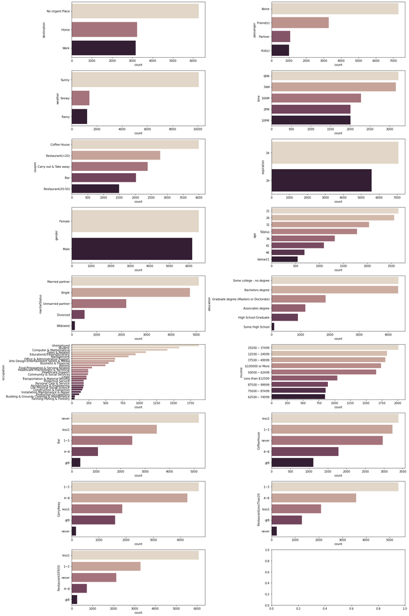

```python
import seaborn as sns
fig, axes = plt.subplots(9, 2, figsize=(20,30))
axes = axes.flatten()

for ax, col in zip(axes, df.select_dtypes('object').columns):
    sns.countplot(y=col, data=df, ax=ax,
                  palette="ch:.25", order=df[col].value_counts().index);

plt.tight_layout()
plt.show();
```

By looking at the counting plot of the categorical features, we realized that there are two kinds of categorical data: ordinal and nominal, we can apply one hot encoder to nominal features, however, ordinal data should be mapped into numerical data so that the inner order can preserve.

- ## Ordinal feature Those ordinal features are:
- **Restaurant20To50**: how many times do you go to a restaurant with average expense per person of \$20 - \\$50 every month?
- **RestaurantLessThan20**: how many times do you go to a restaurant with an average expense per person of less than \$20 every month?
- **CarryAway**: how many times do you get take-away food every month?
- **CoffeeHouse**: how many times do you go to a coffeehouse every month?
- **age**: quite self-explanatory
- **Bar**: how many times do you go to bar every month?
- **income**: income range

  > Convert them into the numerical values in order

```python
freq_map = {
    'never':0,
    'less1':1,
    '1~3':2,
    '4~8':3,
    'gt8':4

}
age_map = {
    'below21': 0,
    '21': 1,
    '26': 2,
    '31': 3,
    '36': 4,
    '41': 5,
    '46': 6,
    '50plus': 7


}
income_map = {
    'Less than $12500':0,
    '$12500 - $24999':1,
    '$25000 - $37499':2,
    '$37500 - $49999':3,
    '$50000 - $62499':4,
    '$62500 - $74999':5,
    '$75000 - $87499':6,
    '$87500 - $99999':7,
    '$100000 or More':8
}
```

```python
freq_col = ['Restaurant20To50','RestaurantLessThan20','CarryAway','CoffeeHouse','Bar']
for i in freq_col:
    df[i] = df[i].map(freq_map)
df['age'] = df['age'].map(age_map)
df['income']= df['income'].map(income_map)
```

**Nominal Feature**

Now, let's have a look of the nominal features:

- **destination**: The destination of the driver
- **passenger**: Type of passenger in the car
- **weather**: Sunny, rainy, or snowy
- **time**: Current time
- **coupon**: Coupon type
- **expiration**: Coupon expiration time
- **gender**: Female or male
- **maritalStatus**: Marital status of the driver
- **occupation**: Occupation of the driver
- **education** Education level of the driver

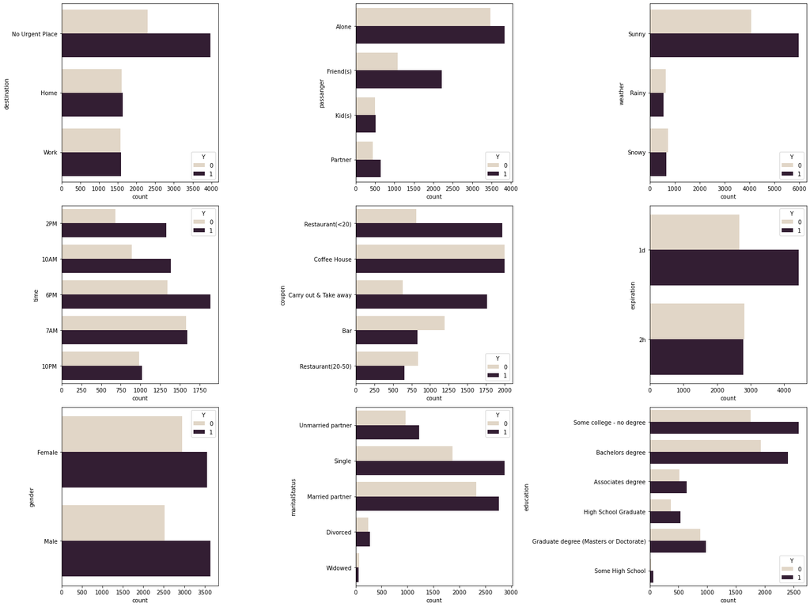

```python
fig, axes = plt.subplots(3, 3, figsize=(20, 15))
axes = axes.flatten()

for ax, col in zip(axes, ['destination', 'passanger', 'weather', 'time',
                          'coupon', 'expiration', 'gender', 'maritalStatus',
                          'education']):
    sns.countplot(y=col, hue='Y', data=df, ax=ax, palette='ch:.25')
plt.tight_layout()
plt.show()
```

- **destination** People that has no urgent place to go has a higher probability to accept the coupon.
- **passenger** If the passengers in car are friends of the driver, they are more likely to accept the coupon.
- **weather** People tend to accept the coupon when it is sunny.
- **time** If the time is too early or too late, the probability of accepting the coupon is lower.
- **coupon** If the coupon is of a coffee house, the probability of accepting the coupon is just the same as rejecting it. If the coupon is of a cheap restaurant or carry out, most people will accept the coupon. If the coupon is of a Bar of expensive Restaurant, people tend to refuse it.
- **expiration** People are more likely to accept a coupon that expires in one day than one in two hours.
- **gender** There is no much difference between gender.
- **maritalStatus** Single people are most likely to accept the coupon.
- **education** Some college, Bachelor or high school graduate are more likely to accept the coupon.

**Numerical Features**

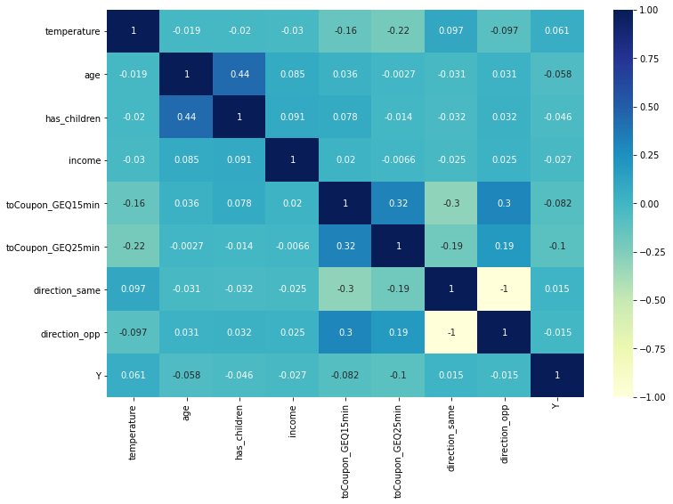

```python
cmap = sns.color_palette('vlag', as_cmap=True)
fig , ax = plt.subplots(figsize = (12,8))

ax = sns.heatmap(df.select_dtypes('int64', 'float64').corr(),
            cmap="YlGnBu",
            annot = True,
           )

plt.show()
```

As the heatmap shows, there are two columns sharing the same information: **direction_same** and **direction_opp**. They indicate whether the restaurant/bar is in the same direction as your current destination. So we decide to delete the **direction_opp** column.

```python
df.drop('direction_opp',axis = 1, inplace = True)
```

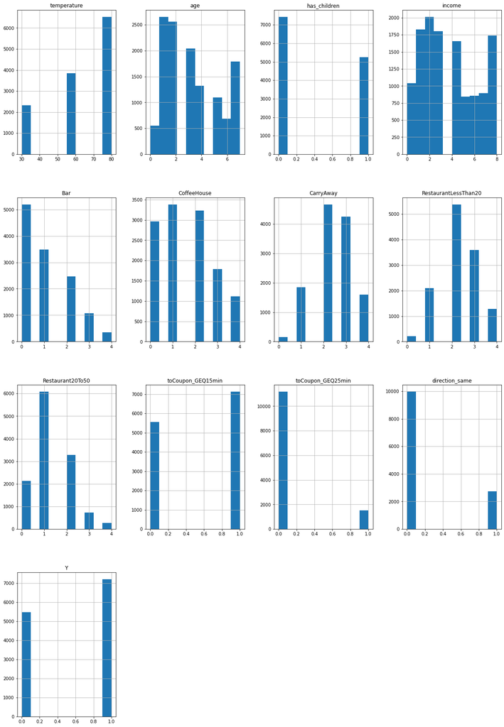

```python
df.hist(figsize=(20,30))
plt.show();
```

After excluding the toCoupon_GEDQ5min feature, we see there are still two features about the driving distance to the Coupon's location: toCoupon_GEQ15min and toCoupon_GEQ25min. They have two possible values: 0 and 1 indicating yes or no to the question: is the driving distance to the restaurant/bar for using the coupon is greater than 15 minutes/25 minutes? We should be able to combine these two columns into one with ordinal data inside: greater than 5 minutes and less than 15 minutes, greater than 15 minutes and less than 25 minutes, and greater than 25 minutes. We believe doing that should be better than treat those two columns using onehotencoder just like different categories.

```python
df.distance = None
df.loc[df['toCoupon_GEQ15min']==0, 'distance'] = 0
df.loc[((df['toCoupon_GEQ15min']==1) & (df['toCoupon_GEQ25min']==0)) , 'distance'] = 1
df.loc[df['toCoupon_GEQ25min']==1, 'distance'] = 2
df['distance'].isna().sum()
```

```
0
```

```python
df['distance'] = df['distance'].astype('int64')
```

```python
df.drop(['toCoupon_GEQ15min','toCoupon_GEQ25min'], axis =1 , inplace = True)
```

```python
df.head()
```

|  | destination | passanger | weather | temperature | time | coupon | expiration | gender | age | maritalStatus | ... | occupation | income | Bar | CoffeeHouse | CarryAway | RestaurantLessThan20 | Restaurant20To50 | direction_same | Y | distance |
| --- | --- | --- | --- | --- | --- | --- | --- | --- | --- | --- | --- | --- | --- | --- | --- | --- | --- | --- | --- | --- | --- |
| 0 | No Urgent Place | Alone | Sunny | 55 | 2PM | Restaurant(<20) | 1d | Female | 1 | Unmarried partner | ... | Unemployed | 3 | 0.0 | 0.0 | NaN | 3.0 | 2.0 | 0 | 1 | 0 |
| 1 | No Urgent Place | Friend(s) | Sunny | 80 | 10AM | Coffee House | 2h | Female | 1 | Unmarried partner | ... | Unemployed | 3 | 0.0 | 0.0 | NaN | 3.0 | 2.0 | 0 | 0 | 0 |
| 2 | No Urgent Place | Friend(s) | Sunny | 80 | 10AM | Carry out & Take away | 2h | Female | 1 | Unmarried partner | ... | Unemployed | 3 | 0.0 | 0.0 | NaN | 3.0 | 2.0 | 0 | 1 | 1 |
| 3 | No Urgent Place | Friend(s) | Sunny | 80 | 2PM | Coffee House | 2h | Female | 1 | Unmarried partner | ... | Unemployed | 3 | 0.0 | 0.0 | NaN | 3.0 | 2.0 | 0 | 0 | 1 |
| 4 | No Urgent Place | Friend(s) | Sunny | 80 | 2PM | Coffee House | 1d | Female | 1 | Unmarried partner | ... | Unemployed | 3 | 0.0 | 0.0 | NaN | 3.0 | 2.0 | 0 | 0 | 1 |

5 rows × 22 columns

Some columns needed to be transformed into categorical columns.

```python
df['direction_same'] = df['direction_same'].astype(str)
df['has_children'] = df['has_children'].astype(str)
```

## Data Preprocessing

Based on the exploratory data analysis, we have almost all categorical variables. There are two sections of feature engineering we saved that can only be done with splitted data: imputation and categorical encoding.

- Data Imputation

We will use simple imputer to replace the missing value with the most frequent item.

- Categorical Encoding

**Further Feature Engineering**

There are other considerations about the feature engineering:

- do we need to apply dimension reduction?

After the OneHotEncoding, we can predict the number of features to reach 50 or more, and the frequency columns are correlated, so it is possible to apply dimension reduction methods like PCA.

- do we need to apply feature expansion?

We can use clustering method to add labels into the dataset as a new feature to help the classification task.

```python
from sklearn.preprocessing import OneHotEncoder , StandardScaler
from sklearn.impute import SimpleImputer
from sklearn.pipeline import Pipeline
from sklearn.model_selection import train_test_split
X = df.drop('Y',axis = 1)
y = df['Y']
```

```python
X_train , X_test ,y_train ,y_test = train_test_split(X,y , test_size=.2,random_state = 0)
```

```python
from sklearn.compose import ColumnTransformer
```

```python
num_feature = X_train.select_dtypes(['int64' , 'float64']).columns
cat_feature = X_train.select_dtypes(['object']).columns

num_trans = Pipeline(steps=[
    ('imputer' , SimpleImputer(strategy = 'most_frequent')),
    ('scale' , StandardScaler())
])

cat_trans = OneHotEncoder()

processor = ColumnTransformer([
    ('num_trans' , num_trans , num_feature),
    ('cat_trans' , cat_trans , cat_feature)
])

X_train = processor.fit_transform(X_train)
X_test = processor.fit_transform(X_test)
```

```python
X_train.shape
```

```
(10147, 73)
```

# 5. Modeling

Now we've got our data split into training and test sets, it's time to build a machine learning model.

We'll train it (find the patterns) on the training set.

And we'll test it (use the patterns) on the test set.

We're going to try 4 different machine learning models:

- 1.Logistic Regression
- 2.K-Nearest Neighbours Classifier
- 3.Support Vector Machine(rbf)
- 4.Random Forest Classifier

## Making a function to train and test all above model at once

```python
# Put all the model in Dictionary

model = {
    'Logistics Regression': LogisticRegression(),
    'KKN': KNeighborsClassifier(),
    'SVM': SVC(),
    'Random Forest Classifier': RandomForestClassifier()
}

def fit_score(X_train , X_test , y_train ,y_test):
    """
    Fits and evaluates given machine learning models.
    models : a dict of differetn Scikit-Learn machine learning models
    X_train : training data (no labels)
    X_test : testing data (no labels)
    y_train : training labels
    y_test : test labels
    """
    model_score = {}
    for name in model.keys():
        model[name].fit(X_train , y_train)
        model_score[name] = model[name].score(X_test , y_test)
    return model_score
```

```python
from sklearn.neighbors import KNeighborsClassifier
from sklearn.svm import SVC
```

```python
result = fit_score(X_train= X_train ,
          X_test = X_test ,
          y_train = y_train ,
          y_test = y_test)
```

```python
result
```

```
{'Logistics Regression': 0.6763894363421363,
 'KKN': 0.6913677571935357,
 'SVM': 0.7406385494678754,
 'Random Forest Classifier': 0.7449743791880173}
```

- ## Model Comparison

```python
result_pd = pd.DataFrame(result , index = ['Accuracy'])
```

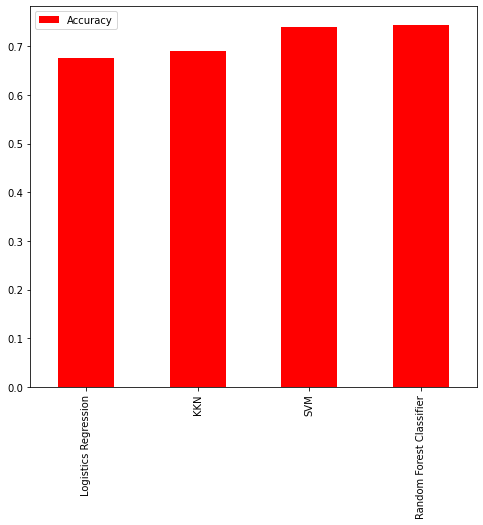

```python
result_pd.T.plot.bar(color = 'red' , figsize=(8,7));
```

Now we've got a baseline model... and we know a model's first predictions aren't always what we should based our next steps off. What should we do?

Let's look at the following:

- Hypyterparameter tuning
- Feature importance
- Confusion matrix
- Cross-validation
- Precision
- Recall
- F1 score
- Classification report
- ROC curve
- Area under the curve (AUC)

## Hyperparameter tuning (by hand)

**Let's Tune with the KNN model**

```python
train_score = []
test_score = []

# setting up the K value for the no. of Neighbour. Take the range b.w 1,21
neighbors = range(1,21)

for i in neighbors:
    knn = KNeighborsClassifier(n_neighbors = i)

    knn.fit(X_train , y_train)
    # insert the training score to the train_score
    train_score.append(knn.score(X_train , y_train))
    # insert the testing score to the test_score
    test_score.append(knn.score(X_test , y_test))
```

```python
train_score
```

```
[0.9986202818567064,
 0.827732334680201,
 0.8509904405242928,
 0.7992510101507835,
 0.7998423179264808,
 0.776781314674288,
 0.7805262639203705,
 0.7707696856213659,
 0.7738247757958017,
 0.7687001084064256,
 0.7668276337833843,
 0.7648566078643935,
 0.7636739923129989,
 0.7592391839952696,
 0.7592391839952696,
 0.7608160047304622,
 0.7595348378831182,
 0.7599290430669163,
 0.7574652606681778,
 0.7559869912289346]
```

```python
test_score
```

```
[0.6610169491525424,
 0.625147812376823,
 0.6771777690185258,
 0.6637761135199054,
 0.6913677571935357,
 0.6791486007094995,
 0.689396925502562,
 0.6795427670476941,
 0.6897910918407568,
 0.6980685849428458,
 0.6929444225463145,
 0.6925502562081198,
 0.6984627512810406,
 0.7012219156484036,
 0.7055577453685455,
 0.7047694126921561,
 0.7055577453685455,
 0.7102877414268821,
 0.7083169097359086,
 0.709105242412298]
```

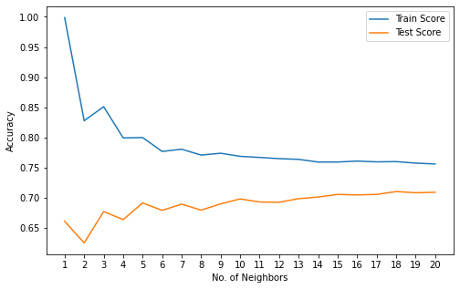

```
Maximum KNN score on the test data : 71.03%
```

```python
plt.subplots(figsize = (8,5))
plt.plot(neighbors , train_score, label = 'Train Score')
plt.plot(neighbors , test_score, label = 'Test Score')
plt.xticks(np.arange(1,21,1))
plt.xlabel('No. of Neighbors')
plt.ylabel('Accuracy')
plt.legend()
plt.show();
print(f'Maximum KNN score on the test data : {max(test_score)*100:.2f}%')
```

- ## Conclusion

  > As we can see that the KNN model is less in all cases than the Support Vector and Random Forest so we leave it